# Unit 3 - Tidyverse

Maciej Kilijański

Slides here

# CRISP-DM data science workflow

> Cross-industry standard process for data mining (CRISP-DM)

## Sample workflow

1. Business understanding - what is the business problem/need?
2. Data understanding - What data do we have vs. need? What are our sources? How is data structured? Where is is stored?
3. Data preparation
4. Modeling - What modeling techniques should we use?
   - What’s the granularity of forecast?
   - What are we predicting (*probability/sales volumes/etc* - format)
   - What are we judging the model on? *Accuracy of the forecast*
5. Evaluation - Which model best meets the business objectives?
6. Deployment - How do stakeholders access the results?

# Tidyverse

> A collection of `R` packages
- Consistent Syntax and philosophy

During the subjects following packages will be used:

- **dplyr** - Data Manipulation
- **tydyR** - Daty Cleaning (Tidying)
- **ggplot2** - Visualization

> Code written using Tidyverse is more **readeable** and **reproducible**

```r
library(tidyverse)
```

## Differences in syntax

### Pipes `%>%`

Pipes allow for composing a sequence of function calls in a more readeable way. Look at the following:

Standard R syntax:

```
print(head(iris))
```

Pipes syntax

```
iris %>% head() %>% print()
```

## Excercise

Sample data

```r
data('mtcars')
```

### Data manipulation with dplyr

#### `filter()` Cars with more than 20 miles per gallon and 6 cylinders

Standard `R`

```r
mtcars_filtered <- mtcars[mtcars[,1] >= 20 & mtcars[,2] == 6,]
mtcars_filtered
```

```
##                 mpg cyl disp  hp drat    wt  qsec vs am gear carb
## Mazda RX4      21.0   6  160 110 3.90 2.620 16.46  0  1    4    4
## Mazda RX4 Wag  21.0   6  160 110 3.90 2.875 17.02  0  1    4    4
## Hornet 4 Drive 21.4   6  258 110 3.08 3.215 19.44  1  0    3    1
```

`R` with `dplyr`

```r
mtcars_filtered <- mtcars %>% filter(mpg > 20) %>% filter (cyl == 6)
mtcars_filtered
```

```
##                 mpg cyl disp  hp drat    wt  qsec vs am gear carb
## Mazda RX4      21.0   6  160 110 3.90 2.620 16.46  0  1    4    4
## Mazda RX4 Wag  21.0   6  160 110 3.90 2.875 17.02  0  1    4    4
## Hornet 4 Drive 21.4   6  258 110 3.08 3.215 19.44  1  0    3    1
```

#### `select()` columns by names or conditions (`head(10)` = 10 top rows)

```r
mtcars %>% select(mpg, cyl, hp) %>% head(10)
```

```
##                    mpg cyl  hp
## Mazda RX4         21.0   6 110
## Mazda RX4 Wag     21.0   6 110
## Datsun 710        22.8   4  93
## Hornet 4 Drive    21.4   6 110
## Hornet Sportabout 18.7   8 175
## Valiant           18.1   6 105
## Duster 360        14.3   8 245
## Merc 240D         24.4   4  62
## Merc 230          22.8   4  95
## Merc 280          19.2   6 123
```

#### Calculate horse power to cylinder ratio

```r
mtcars_mutated <- mtcars %>% mutate(hp_per_cyl = hp / cyl) %>%
select (hp, cyl, hp_per_cyl) %>% head(10)
mtcars_mutated
```

```
##                    hp cyl hp_per_cyl
## Mazda RX4         110   6   18.33333
## Mazda RX4 Wag     110   6   18.33333
## Datsun 710         93   4   23.25000
## Hornet 4 Drive    110   6   18.33333
## Hornet Sportabout 175   8   21.87500
## Valiant           105   6   17.50000
## Duster 360        245   8   30.62500
## Merc 240D          62   4   15.50000
## Merc 230           95   4   23.75000
## Merc 280          123   6   20.50000
```

#### `arrange()` sort rows by columns

```r
mtcars %>% arrange(desc(mpg)) %>% head(10) %>% print()
```

```
##                 mpg cyl  disp  hp drat    wt  qsec vs am gear carb
## Toyota Corolla 33.9   4  71.1  65 4.22 1.835 19.90  1  1    4    1
## Fiat 128       32.4   4  78.7  66 4.08 2.200 19.47  1  1    4    1
## Honda Civic    30.4   4  75.7  52 4.93 1.615 18.52  1  1    4    2
## Lotus Europa   30.4   4  95.1 113 3.77 1.513 16.90  1  1    5    2
## Fiat X1-9      27.3   4  79.0  66 4.08 1.935 18.90  1  1    4    1
## Porsche 914-2  26.0   4 120.3  91 4.43 2.140 16.70  0  1    5    2
## Merc 240D      24.4   4 146.7  62 3.69 3.190 20.00  1  0    4    2
## Datsun 710     22.8   4 108.0  93 3.85 2.320 18.61  1  1    4    1
## Merc 230       22.8   4 140.8  95 3.92 3.150 22.90  1  0    4    2
## Toyota Corona  21.5   4 120.1  97 3.70 2.465 20.01  1  0    3    1
```

#### `summarize()` and `group_by()`

```r
mtcars %>% group_by(cyl) %>%
summarize(mean_mpg = mean(mpg), count = n()) %>% print()
```

```
## # A tibble: 3 × 3
##     cyl mean_mpg count
##   <dbl>    <dbl> <int>
## 1     4     26.7    11
## 2     6     19.7     7
## 3     8     15.1    14
```

### Data Tidying with tidyR

Example messy data

```r
messy_data <- tibble(
  id = 1:4,
  treatment_a = c(3, 4, 6, 8),
  treatment_b = c(5, 6, 7, 9)
)
messy_data
```

```
## # A tibble: 4 × 3
##      id treatment_a treatment_b
##   <int>       <dbl>       <dbl>
## 1     1           3           5
## 2     2           4           6
## 3     3           6           7
## 4     4           8           9
```

#### `gather()`: Convert wide data to long format

```r
tidy_data <- messy_data %>% gather(key = "treatment", value = "response", treatment_a:treatment_b)
tidy_data
```

```
## # A tibble: 8 × 3
##      id treatment   response
##   <int> <chr>          <dbl>
## 1     1 treatment_a        3
## 2     2 treatment_a        4
## 3     3 treatment_a        6
## 4     4 treatment_a        8
## 5     1 treatment_b        5
## 6     2 treatment_b        6
## 7     3 treatment_b        7
## 8     4 treatment_b        9
```

#### `spread()`: Convert long data to wide format

```r
wide_data <- tidy_data %>% spread(key = treatment, value = response)
wide_data
```

```
## # A tibble: 4 × 3
##      id treatment_a treatment_b
##   <int>       <dbl>       <dbl>
## 1     1           3           5
## 2     2           4           6
## 3     3           6           7
## 4     4           8           9
```

#### `separate()`: Split a single column into multiple columns

```r
separated_data <- tidy_data %>% separate(treatment, into = c("treatment", "type"), sep = "_")
separated_data
```

```
## # A tibble: 8 × 4
##      id treatment type  response
##   <int> <chr>     <chr>    <dbl>
## 1     1 treatment a            3
## 2     2 treatment a            4
## 3     3 treatment a            6
## 4     4 treatment a            8
## 5     1 treatment b            5
## 6     2 treatment b            6
## 7     3 treatment b            7
## 8     4 treatment b            9
```

#### `unite()`: Combine multiple columns into one

```r
united_data <- separated_data %>% unite(treatment_type, treatment, type, sep = "_")
united_data
```

```
## # A tibble: 8 × 3
##      id treatment_type response
##   <int> <chr>             <dbl>
## 1     1 treatment_a           3
## 2     2 treatment_a           4
## 3     3 treatment_a           6
## 4     4 treatment_a           8
## 5     1 treatment_b           5
## 6     2 treatment_b           6
## 7     3 treatment_b           7
## 8     4 treatment_b           9
```

### Advanced dplyr Techniques

#### Joins: `left_join()`, `inner_join()`, `right_join()`, `full_join()`

```r
df1 <- tibble(id = 1:3, value1 = c("A", "B", "C"))
df1 %>% print()
```

```
## # A tibble: 3 × 2
##      id value1
##   <int> <chr>
## 1     1 A
## 2     2 B
## 3     3 C
```

```r
df2 <- tibble(id = 2:4, value2 = c("D", "E", "F"))
df2 %>% print()
```

```
## # A tibble: 3 × 2
##      id value2
##   <int> <chr>
## 1     2 D
## 2     3 E
## 3     4 F
```

Includes all values from df1 (left table), excludes all not-matched rows of df2 (right table)

```r
left_join(df1, df2, by = "id")
```

```
## # A tibble: 3 × 3
##      id value1 value2
##   <int> <chr>  <chr>
## 1     1 A      <NA>
## 2     2 B      D
## 3     3 C      E
```

Includes only rows with matching keys in both joined tables

```r
inner_join(df1, df2, by = "id")
```

```
## # A tibble: 2 × 3
##      id value1 value2
##   <int> <chr>  <chr>
## 1     2 B      D
## 2     3 C      E
```

Includes all values from df2 (righ table), excludes all not-matched rows of df1 (left table)

```r
right_join(df1, df2, by = "id")
```

```
## # A tibble: 3 × 3
##      id value1 value2
##   <int> <chr>  <chr>
## 1     2 B      D
## 2     3 C      E
## 3     4 <NA>   F
```

Includes all values

```r
full_join(df1, df2, by = "id")
```

```
## # A tibble: 4 × 3
##      id value1 value2
##   <int> <chr>  <chr>
## 1     1 A      <NA>
## 2     2 B      D
## 3     3 C      E
## 4     4 <NA>   F
```

#### Window functions: `lead()`, `lag()`, `cumsum()`, etc.

```r
mtcars %>% mutate(lag_mpg = lag(mpg), cumsum_mpg = cumsum(mpg)) %>%
select(mpg, lag_mpg, cumsum_mpg) %>% head(10)
```

```
##                    mpg lag_mpg cumsum_mpg
## Mazda RX4         21.0      NA       21.0
## Mazda RX4 Wag     21.0    21.0       42.0
## Datsun 710        22.8    21.0       64.8
## Hornet 4 Drive    21.4    22.8       86.2
## Hornet Sportabout 18.7    21.4      104.9
## Valiant           18.1    18.7      123.0
## Duster 360        14.3    18.1      137.3
## Merc 240D         24.4    14.3      161.7
## Merc 230          22.8    24.4      184.5
## Merc 280          19.2    22.8      203.7
```

### `ggplot2`

```r
library(ggplot2)
```

#### Defining data for plot

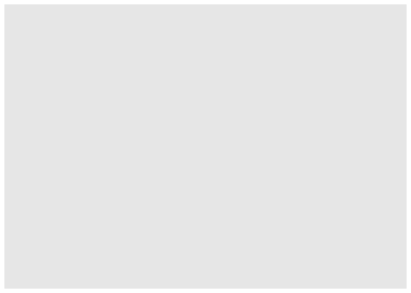

```r
ggplot(data = mtcars)
```

#### Mapping points on the plot

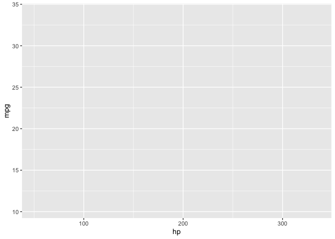

```r
ggplot(mtcars, mapping = aes(x = hp, y = mpg))
```

#### Creating a scatterplot

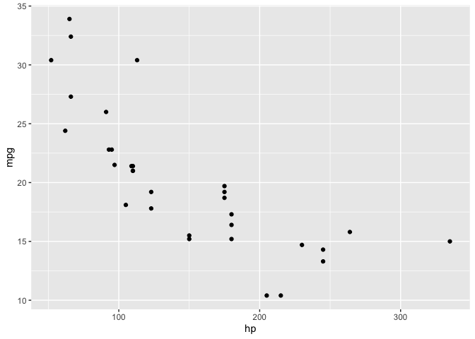

```r
ggplot(mtcars, mapping = aes(x = hp, y = mpg)) +
  geom_point()
```

#### Adding fit and trendline overlay + title and axis names

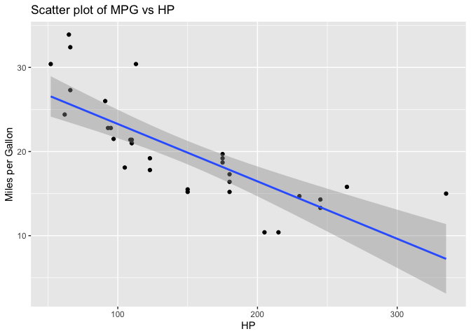

```r
ggplot(mtcars, mapping = aes(x = hp, y = mpg)) +
  # to create a scatterplot
  geom_point() +
  # to fit and overlay a trendline
  geom_smooth(formula = y ~ x, method = "lm") +
  # to add a title and name the axes
  labs(title = "Scatter plot of MPG vs HP", x = "HP", y = "Miles per Gallon")
```

#### Adding another mapping - cylinders depicted by colors

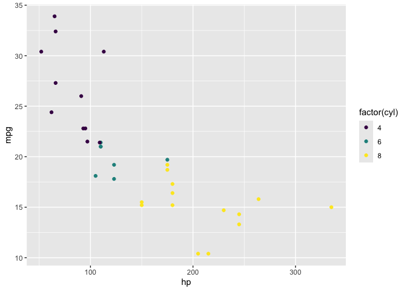

```r
ggplot(mtcars, mapping = aes(x = hp, y = mpg, color = factor(cyl))) +
  geom_point() +
  scale_colour_viridis_d()
```

#### Colors are hard to distinguish, changing them to manual scale

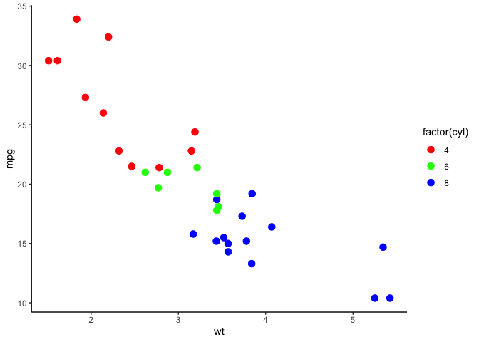

```r
ggplot(mtcars, aes(x = wt, y = mpg, color = factor(cyl))) +
  geom_point(size = 3) +
  scale_color_manual(values = c("red", "green", "blue")) +
  theme_classic()
```

#### Faceting: facet_wrap(), facet_grid()

Need to show the relationship divided by sub-groups. Example: cylinders.

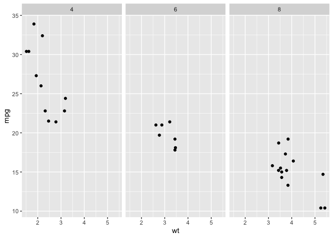

```r
ggplot(mtcars, aes(x = wt, y = mpg)) +
  geom_point() +
  facet_wrap(~ cyl)
```

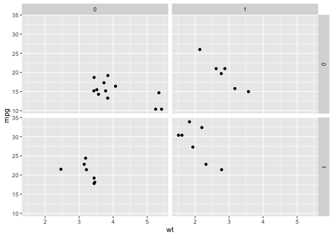

```r
ggplot(mtcars, aes(x = wt, y = mpg)) +
  geom_point() +
  facet_grid(vs ~ am)
```